# Activity Data Analysis

Peter Zeglen

February 21, 2016

## Loading and preprocessing the data

We will go ahead and read the data into R and use the head() function to get an idea of how it looks.

```r
table <- read.csv("activity.csv")
head(table)
```

```
##   steps       date interval
## 1    NA 2012-10-01        0
## 2    NA 2012-10-01        5
## 3    NA 2012-10-01       10
## 4    NA 2012-10-01       15
## 5    NA 2012-10-01       20
## 6    NA 2012-10-01       25
```

## What is the mean total number of steps taken per day?

```r
splitted <- split(table,f=table$date)
mean2 <- function(x){mean(x$steps,na.rm = TRUE)}
PerDay <- lapply(splitted,FUN = mean2)
```

We then use PerDay to make a histogram and find the mean and median.

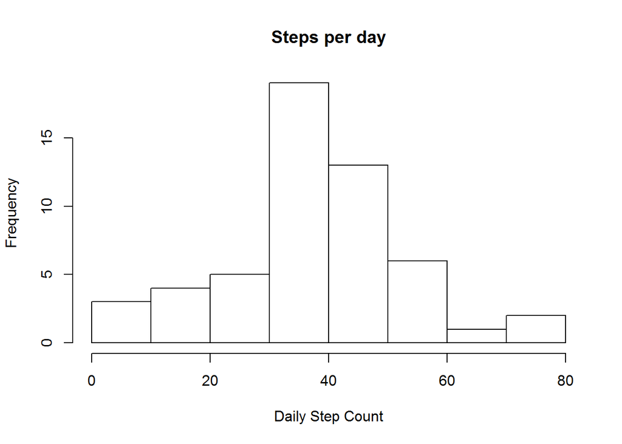

```r
hist(unlist(PerDay),xlab = "Daily Step Count",main = "Steps per day")
```

```r
mean(unlist(PerDay),na.rm = TRUE)
```

```
## [1] 37.3826
```

```r
median(unlist(PerDay),na.rm = TRUE)
```

```
## [1] 37.37847
```

The mean is 37.3826 and the median is 37.37847..

## What is the average daily pattern?

To find the daily patterns, we perform a similar function, except this time we split by time of day.

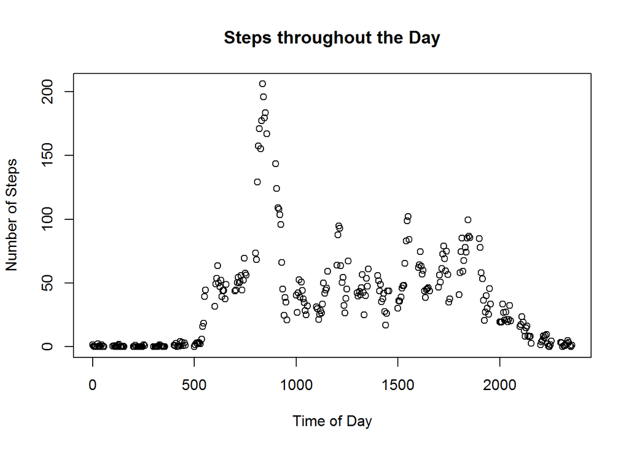

```r
splitBySlot <- split(table,f=table$interval)
mean2 <- function(x){mean(x$steps,na.rm = TRUE)}
PerTime <- lapply(splitBySlot,FUN = mean2)
plot(names(PerTime),unlist(PerTime),ylab = "Number of Steps",xlab = "Time of Day",main = "Steps throughout the Day")
```

To find the maximum, we combine the interval time and the steps into a matrix “mat”. We then take the max of the steps and check the corresponding interval.

```r
mat <- cbind(names(PerTime),unlist(PerTime))
mat[which.max(mat[,2]),1]
```

```
##   835
## "835"
```

## Imputing Missing Values

Now, we are going to replace the missing data. First, let us see how many values we have to replace.

```r
length(is.na(table['steps']))
```

```
## [1] 17568
```

```r
interNA <- unlist(table$interval)
stepsNA <- unlist(table$steps)
timeNA <- unlist(PerTime)
m <- data.frame(cbind(interNA,stepsNA))
m$correctedSteps <- m$stepsNA
m$correctedSteps[is.na(m$correctedSteps)] <- 0
m$predicted <- PerTime[as.character(interNA)]
m$filled <- m$correctedSteps+as.numeric(m$correctedSteps==0)*as.numeric(m$predicted)
table <- read.csv("activity.csv")
newTable <- table
newTable$steps <- m$filled
head(newTable)
```

```
##       steps       date interval
## 1 1.7169811 2012-10-01        0
## 2 0.3396226 2012-10-01        5
## 3 0.1320755 2012-10-01       10
## 4 0.1509434 2012-10-01       15
## 5 0.0754717 2012-10-01       20
## 6 2.0943396 2012-10-01       25
```

That “filled” column in m tells us the “inferred” data. We combine all this into the “new table”. Next we make our histogram.

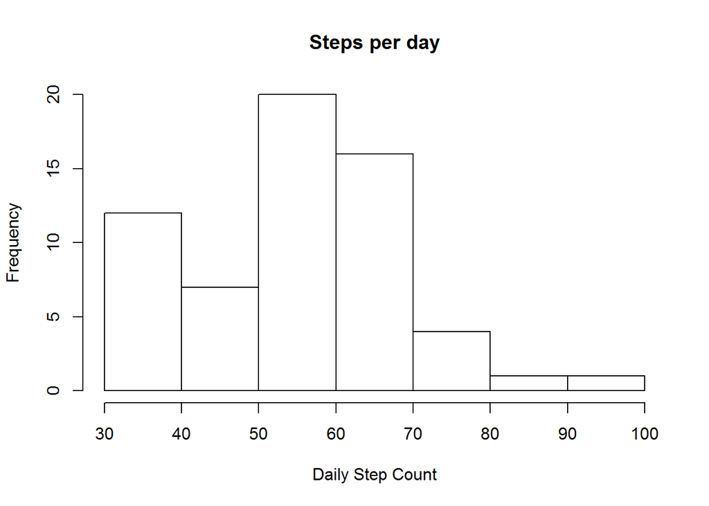

```r
splitted <- split(newTable,f=newTable$date)
mean2 <- function(x){mean(x$steps,na.rm = TRUE)}
PerDay <- lapply(splitted,FUN = mean2)
hist(unlist(PerDay),xlab = "Daily Step Count",main = "Steps per day")
```

```r
mean(unlist(PerDay),na.rm = TRUE)
```

```
## [1] 55.12496
```

```r
median(unlist(PerDay),na.rm = TRUE)
```

```
## [1] 54.99214
```

## Are there differences in activity patterns between weekdays and weekends?

We first determine which dates are weekends and weekdays. We split newtable into two tables (one for weekends, one for weekdays) and add a factored column to the newtable.

```r
newTable$week <- weekdays(as.Date(newTable$date))
x <- newTable$week=="Sunday"
y <- newTable$week=="Saturday"
tableWE <- newTable[x|y,]
tableWD <- newTable[!x&!y,]
newTable$week <- x|y
newTable$week <- factor(newTable$week,levels = c(TRUE,FALSE),labels = c("Weekend","Weekday"))
tableWE$interval <- factor(tableWE$interval)
tableWD$interval <- factor(tableWD$interval)
```

newTable now has our factored column.

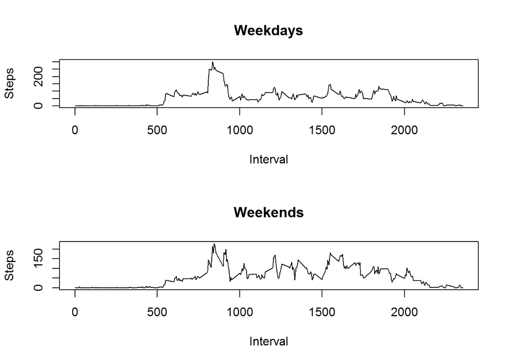

```r
splitWE <- split(tableWE,f=tableWE$interval)
PerWEInt <- lapply(splitWE,FUN = mean2)
splitWD <- split(tableWD,f=tableWD$interval)
PerWDInt <- lapply(splitWD,FUN = mean2)
par(mfrow = c(2,1))
plot(names(PerWDInt),unlist(PerWDInt),xlab = "Interval",ylab = "Steps",main = "Weekdays",type = "l")
plot(names(PerWEInt),unlist(PerWEInt),xlab = "Interval",ylab = "Steps",main = "Weekends",type = "l")
```